# Milestone #4

Fall 2022

Sam Gorman, Bria Larson, Lyndsay Miles

### Joining data frames

First, need to group by country code to get number of total cases per country and then calculate incidence per 100,000 people by country

```r
total_risk_by_country <- euro_mpx_clean %>%
  group_by(countrycode) %>%
  summarise(cases = sum(cases)) %>%
  arrange(countrycode) %>%
  left_join(pop_denom_small, by = c("countrycode" = "geo")) %>%
  mutate(total_risk = round((cases/population * 100000),2))

str(total_risk_by_country)
```

```
## tibble [31 × 5] (S3: tbl_df/tbl/data.frame)
##  $ countrycode: chr [1:31] "AT" "BE" "BG" "CH" ...
##  $ cases      : num [1:31] 231 671 4 431 4 ...
##  $ time_period: num [1:31] 2022 2022 2022 2022 2022 ...
##  $ population : num [1:31] 8978929 11631136 6838937 8736510 904705 ...
##  $ total_risk : num [1:31] 2.57 5.77 0.06 4.93 0.44 0.39 4 2.88 0.75 0.49 ...
```

Join the cleaned euro_mpx to a filtered, clean pop_denom

```r
euro_mpx_joined <- left_join(euro_mpx_clean, pop_denom_small,
                           by = c("countrycode" = "geo"))

monthly_risk_by_country <- euro_mpx_joined %>%
  select(-c(countryexp, date, time_period)) %>%
  group_by(countrycode, month) %>%
  mutate(monthly_cases = sum(cases),
         monthly_risk = round((monthly_cases/population * 100000),2)) %>%
  summarize(mean_risk = mean(monthly_risk)) %>%
  pivot_wider(names_from = month, values_from = mean_risk)
```

Calculate % of population by age strata

```r
census_stats_perc <- census_stats_clean %>%
  left_join(country_regions_clean, by = "country_code") %>%
  group_by(name, country_code, sex, age) %>%
  summarize(strata_pop = sum(pop)) %>%
  ungroup() %>%
  group_by(country_code) %>%
  mutate(total_pop = sum(strata_pop)) %>%
  mutate(perc_pop = round(strata_pop/total_pop, 2))
```

### Visualizations

**Chart:** Percentage of young men (age 15-29) in European Countries, 2011

```r
mod_census_stats_v4 <- census_stats_perc %>%
  filter(sex == "M", age == "Y15-29") %>%
  mutate(perc_young_men = (strata_pop/total_pop)*100)%>%
  arrange(perc_young_men)
```

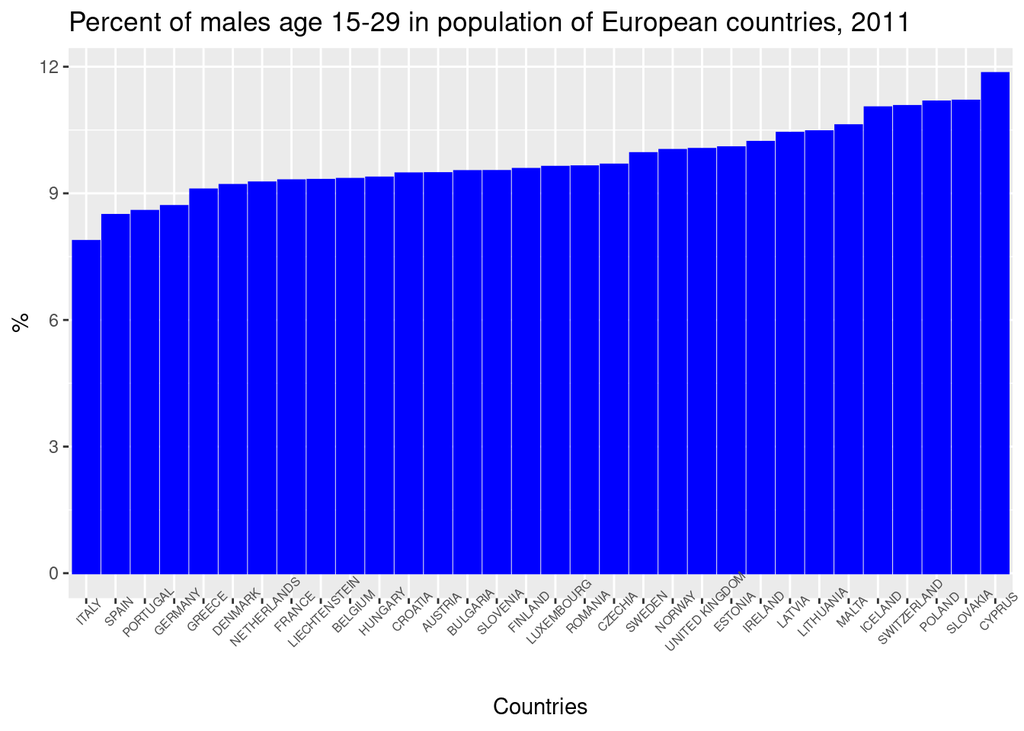

```r
# factor country_code variable
mod_census_factor <- mod_census_stats_v4

mod_census_factor$country_code <-factor(mod_census_factor$country_code,
              levels = mod_census_factor$country_code[order(mod_census_factor$perc_young_men)])

mod_census_factor$name <- factor(mod_census_factor$name,
                                 levels = mod_census_factor$name[order(mod_census_factor$perc_young_men)])

#Chart of percentage of men age 15-29 in population by country

ggplot(mod_census_factor, aes(x= name, y= perc_young_men)) +
    geom_bar(stat = "identity", color = "blue", fill = "blue") +
  labs(x = "Countries", y = "%" ,
   title = "Percent of males age 15-29 in population of European countries, 2011") +
  theme(axis.text.x = element_text(size = 6, angle = 45)) #+theme_bw()
```

Interpretation: The percentage total population that are men age 15 - 29 varies slightly (7.9 % - 11.8 %) among European countries.

**Chart:** Percent of men age 15-29 by European countries, 2011

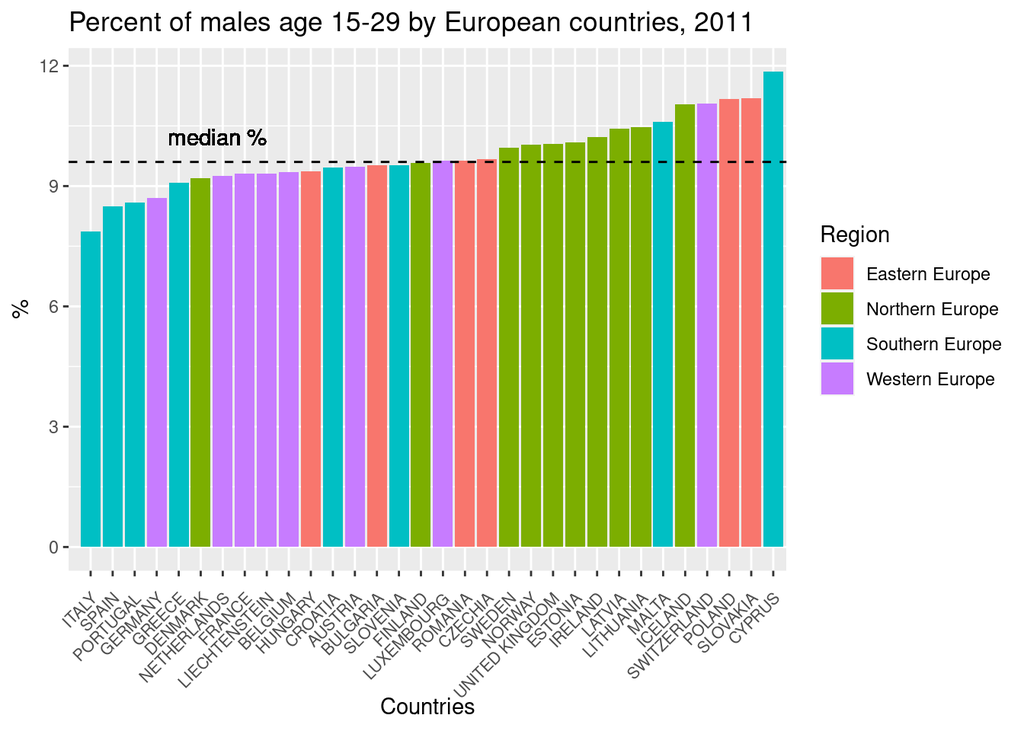

```r
mod_census_regions <- left_join(mod_census_factor, country_regions_clean)
# factor country_code variable AGAIN
mod_census_factor_2 <- mod_census_regions
mod_census_factor_2$country_code <-factor(mod_census_factor_2$country_code,
              levels = mod_census_factor_2$country_code[order(mod_census_factor_2$perc_young_men)])

mod_census_factor_2$name <-factor(mod_census_factor_2$name,
              levels = mod_census_factor_2$name[order(mod_census_factor_2$perc_young_men)])

med_val <- median(mod_census_regions$perc_young_men)
# med_val

ggplot(mod_census_factor_2,
    aes(x= name, y= perc_young_men, fill = sub_region)) +
    geom_bar(stat = "identity") +
    geom_hline(yintercept = med_val, linetype = 2) +
    geom_text(aes(0,med_val,label = "median %", vjust = -1, hjust = -1)) +
  labs(x = "Countries", y = "%" ,
   title = "Percent of males age 15-29 by European countries, 2011",
   fill = "Region") +
  theme(axis.text.x = element_text(size = 8, angle = 45, hjust = 1, vjust = 0.9))
```

Interpretation: The percentage total population that are men age 15 - 29 varies slightly by European region. Most of the countries in Northern Europe had percentages of young men above the median value of 9.6%, while most countries in Western Europe had percentages of young men below the median value of 9.6%.

**Scatterplot:** Ecologic Analysis Comparing Monkeypox Case Rates per 100,000 to the percentage of the population that is male and aged 15-29.

```r
#create smaller data set to join to euro_mp for ecological analysis
mod_census_to_join <- mod_census_stats_v4 %>%
  select(country_code, perc_young_men)
```

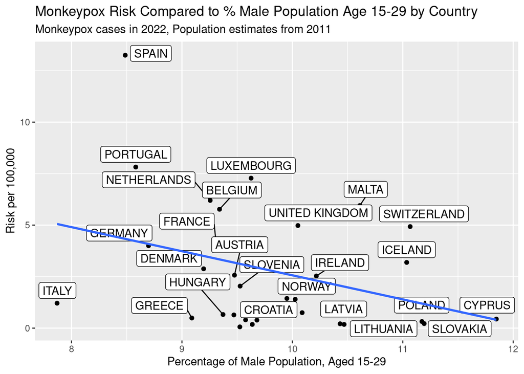

```r
#what is the incidence per country (x)
#what percent of the population is between 15 and 29? (y)
young_perc <- mod_census_stats_v4 %>%
  left_join(total_risk_by_country, by = c("country_code" = "countrycode")) %>%
  filter(country_code != "LI")

ggplot(young_perc, aes(x = perc_young_men, y = total_risk)) +
 geom_point() +
  geom_label_repel(aes(label=name, size = NULL), nudge_y = 0.5) +
  geom_smooth(fullrange=TRUE, method = "lm", se = FALSE)+
  labs(x = "Percentage of Male Population, Aged 15-29", y = "Risk per 100,000",
                  title = "Monkeypox Risk Compared to % Male Population Age 15-29 by Country",
       subtitle = "Monkeypox cases in 2022, Population estimates from 2011")
```

Interpretation: There does not appear to be a strong correlation between the percentage of men age 15-29 in a country and the country’s total risk of Monkeypox per 100,000 people. The range of % of men in this age category is 7.86-11.85%, and the range of Monkeypox risk by country is 0.06-13.27.

**Table and chart:** Monthly Monkeypox Incidence by European Region

```r
population_by_region <- euro_mpx_joined %>%
  left_join(country_regions_clean, by = c("countrycode" = "country_code"))
```

```r
monthly_risk_by_region <- population_by_region %>%
  select(c(countrycode, cases, month, population, sub_region)) %>%
  group_by(sub_region, month) %>%
  mutate(month = case_when(
    month %in% 5 ~ "May",
    month %in% 6 ~ "June",
    month %in% 7 ~ "July",
    month %in% 8 ~ "August"),
   month = factor(month, ordered = T,
                             levels = c("May",
                                        "June",
                                        "July",
                                        "August")),
        monthly_cases = sum(cases),
         region_total_pop = sum(population),
         monthly_risk = round((monthly_cases/region_total_pop * 100000),3)) %>%
  summarize(mean_risk = mean(monthly_risk))
#%>%
 # pivot_wider(names_from = month, values_from = monthly_risk)

monthly_risk_region_table <- monthly_risk_by_region %>%
  pivot_wider(names_from = month, values_from = mean_risk)

#monthly_risk_by_country <- euro_mpx_joined %>%
  #select(-c(countryexp, date, time_period)) %>%
 # group_by(countrycode, month) %>%
 # mutate(monthly_cases = sum(cases),
      #   monthly_risk = round((monthly_cases/population * 100000),3)) %>%
  #summarize(mean_risk = mean(monthly_risk)) %>%
 # pivot_wider(names_from = month, values_from = mean_risk)
```

```r
kable(monthly_risk_region_table,
      booktabs = T,
      col.names = c("European Region","May", "Jun", "Jul", "Aug"),
      caption = "Monthly Incidence of Monkeypox per 100k May-Aug 2022") %>%
  footnote(general = "European Centre for Disease Prevention and Control & EuroStat",
           general_title = "Data Source") %>%
  kable_styling(full_width = T)
```

Monthly Incidence of Monkeypox per 100k May-Aug 2022

| European Region | May | Jun | Jul | Aug |
| --- | --- | --- | --- | --- |
| Eastern Europe | 0.000 | 0.002 | 0.004 | 0.005 |
| Northern Europe | 0.009 | 0.037 | 0.044 | 0.041 |
| Southern Europe | 0.017 | 0.047 | 0.091 | 0.059 |
| Western Europe | 0.004 | 0.036 | 0.070 | 0.046 |

Data Source  
European Centre for Disease Prevention and Control & EuroStat

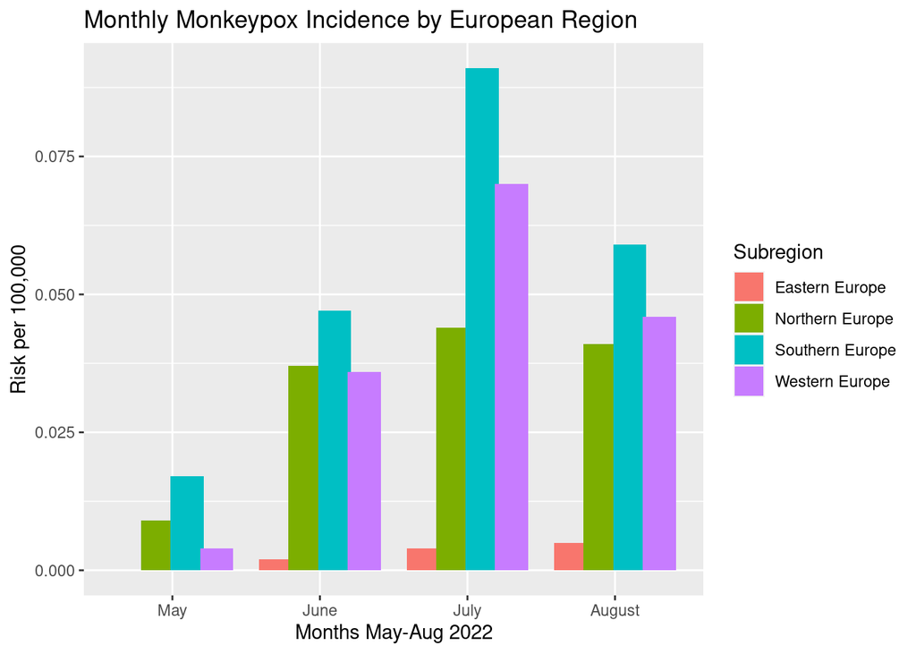

```r
ggplot(monthly_risk_by_region, aes(x = month, y = mean_risk)) +
  geom_bar(aes(fill = sub_region), stat = "identity", position = position_dodge(width = 0.8)) +
             labs(x = "Months May-Aug 2022", y = "Risk per 100,000", fill="Subregion",
                  title = "Monthly Monkeypox Incidence by European Region")
```

Interpretation: The above table and chart show us that monthly incidence of monkeypox per 100,000 people increases between May and July 2022 (peaking during the month of July) and begins to decrease in August 2022. Incidence is highest in the southern region of Europe in July 2022( 0.09/100,000) followed by western Europe in July 2022 (0.07/100,000).